## Introduction

In this new analysis I will add two variables:

- Agriculture (% of GDP)
- Continent

The main goal of the analysis is to explore the relation between all the variables across all the continents.

## Getting and Cleaning Data

Data has been obtained and downloaded from [Gapminder](http://www.gapminder.org/data/).

- **Agricultural land (% of land area)**,
- **Forest coverage (%)**,
- **Agriculture (% of GDP),**
- **Countries per Continent**

**Note:** Since the goal of this course is not Getting and Cleaning data, I’ve manually removed years from Agriculture data to make it easier to read and clean. *This is not a recomended practice*.

```r
a.coverage <- read.csv("./data//agriculture land.csv",
                   col.names = c("Country","1990","2000","2005"))
f.coverage <- read.csv("./data//indicator_forest coverage.csv",
                   col.names = c("Country","1990","2000","2005"))
a.gdp <- read.csv("./data//agriculture p of GDP.csv",
                  col.names = c("Country","1990","2000","2005"))
continents <- read.csv("./data//Countries-Continents.csv")

a.coverage <- melt(a.coverage, id.vars = c("Country"))
names(a.coverage) <- c("Country","Year","Agriculture.Coverage")
f.coverage <- melt(f.coverage, id.vars = c("Country"))
names(f.coverage) <- c("Country","Year","Forest.Coverage")
a.gdp <- melt(a.gdp, id.vars = c("Country"))
names(a.gdp) <- c("Country","Year","Agriculture.GDP")


data <- merge(a.coverage,f.coverage, by=c("Country","Year"))
data <- merge(data, a.gdp, by =c("Country", "Year"))
data <- merge(data, continents, by = c("Country"))

data$Year <- gsub("X","",data$Year)
data$Year <- as.factor(data$Year)
data$Agriculture.Coverage <- gsub(",",".",data$Agriculture.Coverage)
data$Agriculture.Coverage <- as.numeric(data$Agriculture.Coverage)
data$Forest.Coverage <- gsub(",",".",data$Forest.Coverage)
data$Forest.Coverage <- as.numeric(data$Forest.Coverage)
data$Agriculture.GDP <- gsub(",",".", data$Agriculture.GDP)
data$Agriculture.GDP <- as.numeric(data$Agriculture.GDP)

data <- data[complete.cases(data),]

rm(a.coverage,f.coverage, a.gdp, continents)

head(data)
```

```
##       Country Year Agriculture.Coverage Forest.Coverage Agriculture.GDP
## 2 Afghanistan 2005             58.12367            1.33       39.480416
## 4     Albania 2005             39.30657           28.98       22.800000
## 5     Albania 1990             40.91241           28.80       35.900790
## 6     Albania 2000             41.75182           28.07       29.130583
## 7     Algeria 2000             16.80326            0.90        8.879884
## 8     Algeria 1990             16.23855            0.75       11.358267
##   Continent
## 2      Asia
## 4    Europe
## 5    Europe
## 6    Europe
## 7    Africa
## 8    Africa
```

Seems that data is ready to be processed…

## Data Processing

Let’s do some explorative charts, nothing too formal, just to take a look at the data…

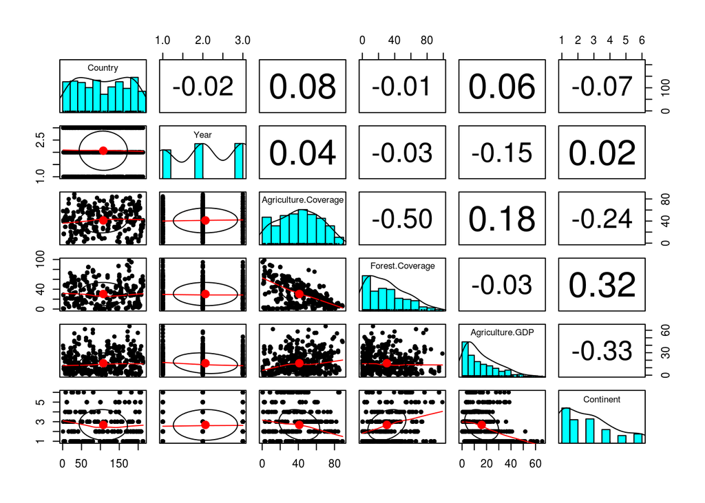

```r
pairs.panels(data)
```

There isn’t too much correlation between variables. The most interesting relation is between Agriculture.Coverage and Forest.Coverage as I analized in my previuous exercise. By looking at the Agriculture.GDP histogram it seems that only a few countries depends on its agriculture.

Let’s take a closer look to Agriculture.GDP in 2005:

```r
summary(subset(data, Year == 2005)$Agriculture.GDP)
```

```
##    Min. 1st Qu.  Median    Mean 3rd Qu.    Max.
##  0.0542  3.5210 10.1300 13.8400 21.2100 51.5700
```

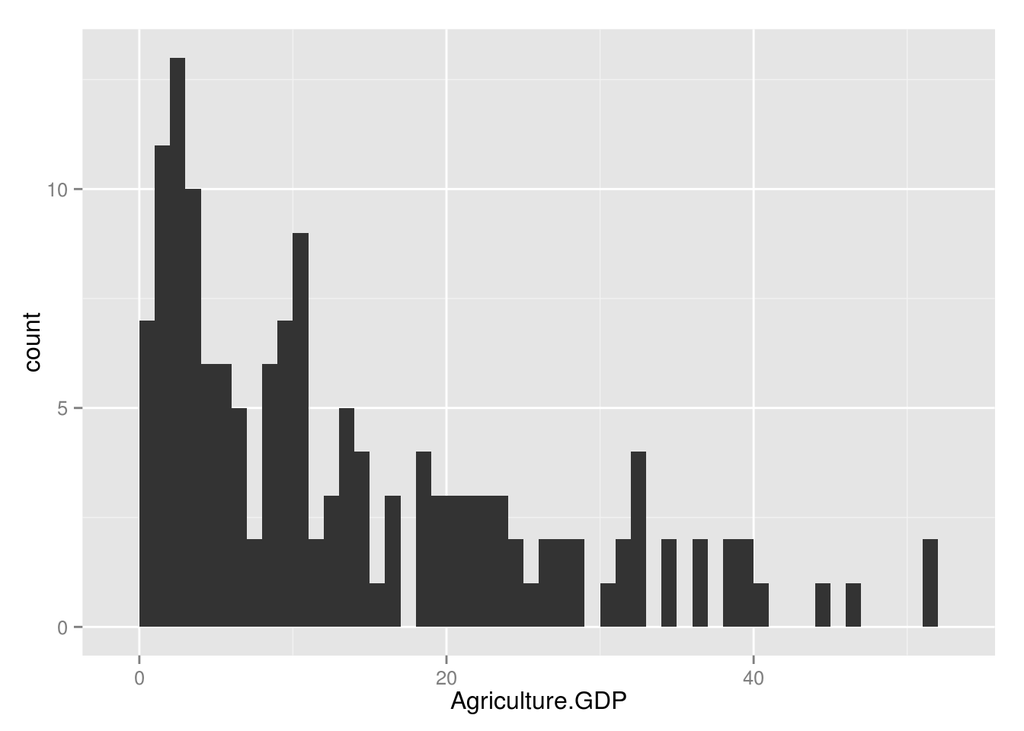

```r
ggplot(subset(data, Year == 2005), aes(x = Agriculture.GDP)) +
  geom_histogram(binwidth = 1)
```

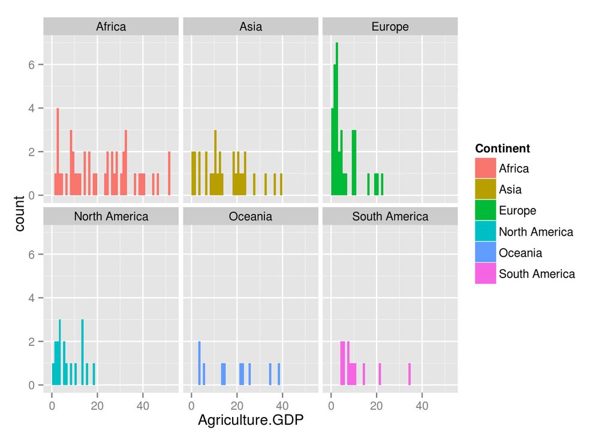

```r
ggplot(subset(data, Year == 2005), aes(x= Agriculture.GDP)) +
  geom_histogram(aes(fill = Continent),binwidth = 1) +
  facet_wrap(~ Continent)
```

#### Plotting Variable Means over Time

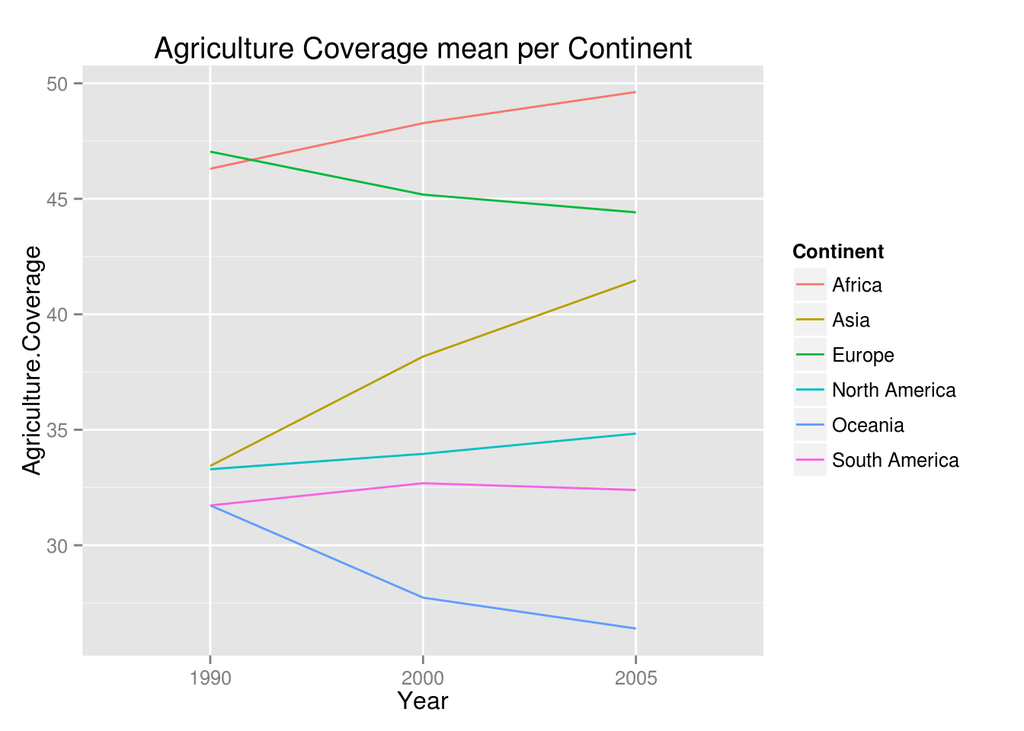

```r
ggplot(data, aes(x = Year, y= Agriculture.Coverage, group=Continent)) +
  geom_line(stat = "summary", aes(color = Continent), fun.y = mean) +
  ggtitle("Agriculture Coverage mean per Continent")
```

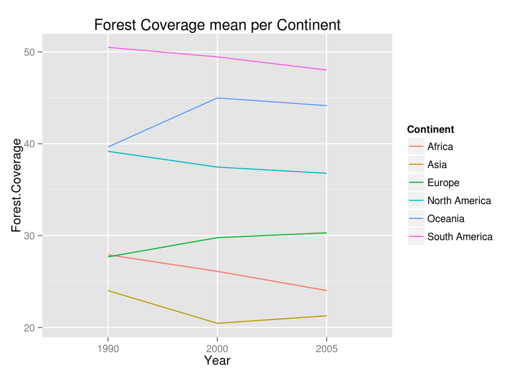

```r
ggplot(data, aes(x = Year, y= Forest.Coverage, group=Continent)) +
  geom_line(stat = "summary", aes(color = Continent), fun.y = mean) +
  ggtitle("Forest Coverage mean per Continent")
```

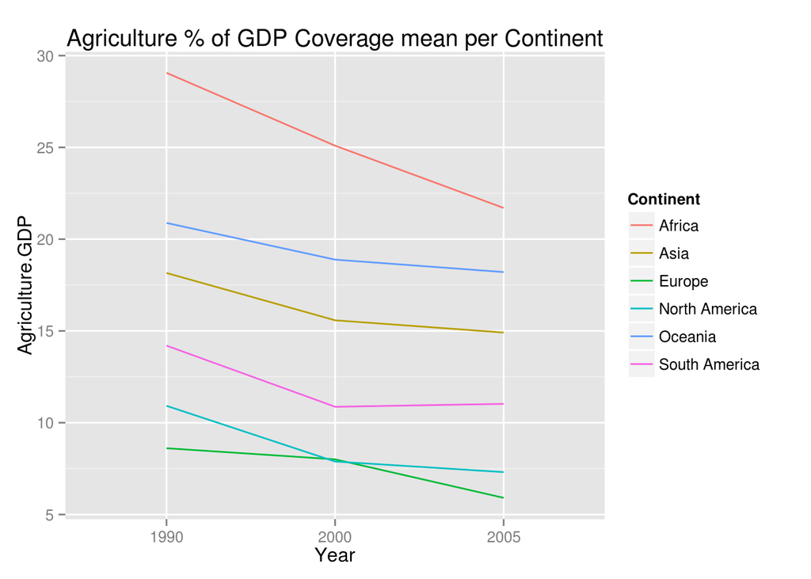

```r
ggplot(data, aes(x = Year, y= Agriculture.GDP, group=Continent)) +
  geom_line(stat = "summary", aes(color = Continent), fun.y = mean) +
  ggtitle("Agriculture % of GDP Coverage mean per Continent")
```

It looks like all the Agriculture % of GDP decreased in the World from 1990 to 2005 **even when** Agriculture Coverage increased in Africa, Asia, North America, and South America.

#### Agriculture Ratio

Can **Agriculture.GDP** over **Agriculture.Coverage** may be used as a measure for the performance of the farms?

If two countries have different Agriculture.GDP but the same Agriculture.Coverage could imply that the biggest Agriculture.GDP has a better use of the soil. If 10% of my land produces the 20% of my GDP, then I’m making a better use of the soil than a country that uses 10% of their land to produce the 5% of the GDP.

```r
data$Agriculture.Ratio <- data$Agriculture.GDP / data$Agriculture.Coverage
summary(data$Agriculture.Ratio)
```

```
##      Min.   1st Qu.    Median      Mean   3rd Qu.      Max.
##  0.008936  0.146700  0.349400  0.834700  0.619700 19.790000
```

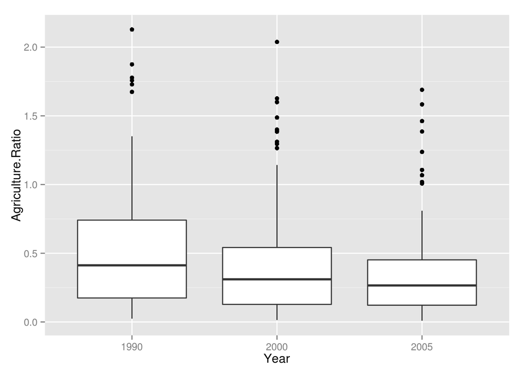

```r
ggplot(subset(data, Agriculture.Ratio < quantile(Agriculture.Ratio, probs = 0.95)),
              aes(x = Year, y = Agriculture.Ratio)) + geom_boxplot()
```

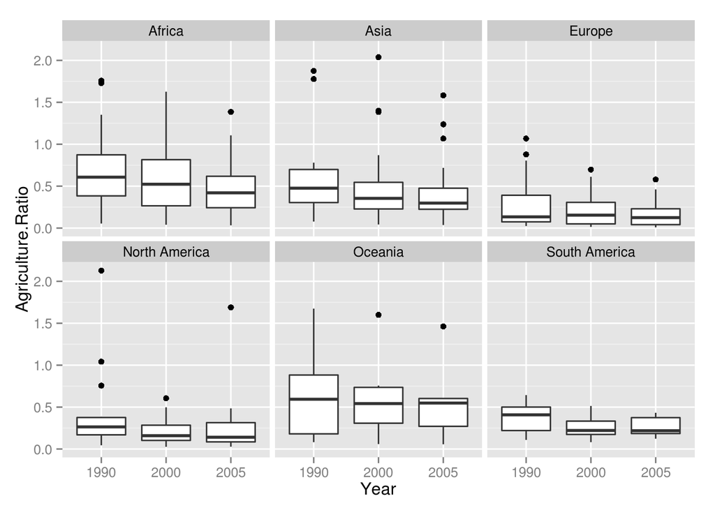

```r
ggplot(subset(data, Agriculture.Ratio < quantile(Agriculture.Ratio, probs = 0.95)),
              aes(x = Year, y = Agriculture.Ratio)) + geom_boxplot() + facet_wrap(~Continent)
```

## Conclusion

Facts extracted so far:

- It seems that around the world, the Forest Coverage % per Country didn’t change so much,
- This doesn’t mean that the Total Forest Coverage in the world didn’t change drastically, but this can mean that most of the countries has a firm policy about preserving forest.
- This also can mean that the main deforestation in the world is being done by a few countries.
- Even when countries are spending more and more land on Agriculture this doesn’t mean that its contribution to the GDP is increasing, just the oposite.
- The most remarcable case is Asia, that has increased its Agriculture Coverage by almost 10% but the Agriculture.GDP decreased by 3%

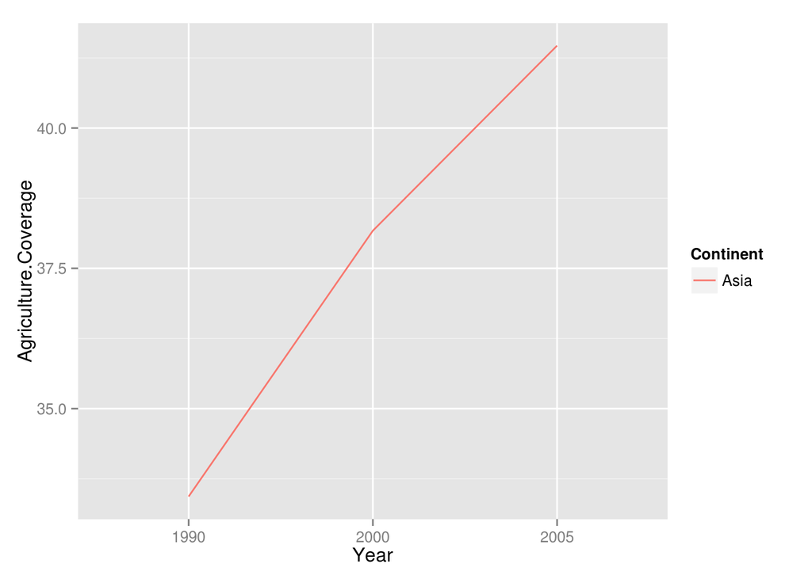

```r
ggplot(subset(data, Continent == "Asia"),
       aes(x = Year, y = Agriculture.Coverage, group = Continent)) +
  geom_line(stat = "summary", aes(color = Continent), fun.y = mean)
```

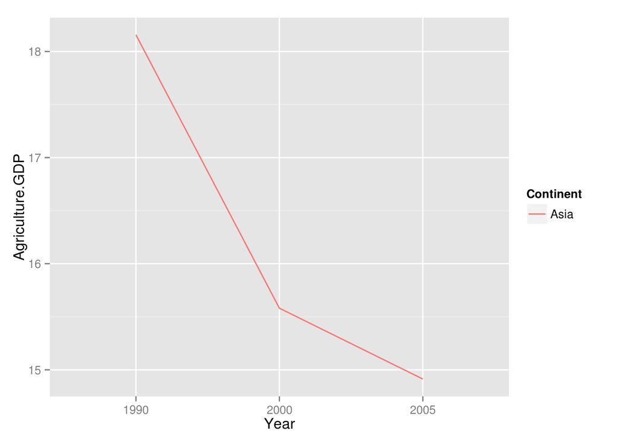

```r
ggplot(subset(data, Continent == "Asia"),
       aes(x = Year, y = Agriculture.GDP, group = Continent)) +
  geom_line(stat = "summary", aes(color = Continent), fun.y = mean)
```